# Predicting forest fire occurances in Northeastern Portugal

Final Report Group 2

Margot Vore, Ana Einolghozati, Gautham Pughazhendhi, Hatef Rahmani

11/27/2021

# Summary

We have created a simple prediction model to predict the size of forest fires using weather and soil moisture properties. We explore a data set from northeastern Portugal that contains spatial features, temporal features, soil moisture indices, and weather features to predict the size of wildfires within the Montesinho natural park. We create a Support Vector Regression (SVR) model using the soil moisture variables along with temperature, relative humidity, wind, spatial coordinates, as well as season. After removing outliers using Cook’s Distance method, we optimized our model using mean absolute area (MAE) and root mean square error (RMSE). Our optimized model, with $C = 1.88$ and $\gamma = 0.48$, produces a MAE of 8.686 and an RMSE of 28.46 on the unseen test data set, which is good for our range of area burned values from 0 to 1090 ha.

# Introduction

Forest fires are a common occurrence in both British Columbia and globally. In British Columbia, unprecedented amounts of forest have burned in the recent decades, with over 1,350,000 ha burning in 2018 alone, costing the Canadian government over $615 million dollars (British Columbia 2021). Due to the complexity and variability in landscapes, fuel characteristics, climate patterns, and man-made infrastructure, it is incredibly hard to determine how large a fire will be, the intensity at which it will burn, and how it will move. Predicting such fire characteristics would benefit local communities and may influence resource allocation decisions during fire events. Our aim is to create a machine learning model that can predict how much area a particular fire will burn. While our model will be simple, it will begin to explore the interactions between climate, soil properties, and area burned by forest fires.

# Methods

## Data

For our simple prediction model, we have chosen a data set originally used in (P. Cortex, A. Morais 2007), which represents forest fire areas in Montesinho natural park located in the northeastern region of Portugal. The data was sourced from the UCI Machine Learning Repository (Dua and Graff (2017)) and can be found [here](https://archive.ics.uci.edu/ml/datasets/forest+fires). The data was collected between 2000 and 2003 leading to 517 records consisting of two spatial features (x and y coordinates), two temporal features (month and day of the week), four soil moisture indices for different soil layers (FFMC (Fine fuel moisture code), DMC (duff moisture code), DC (drought code), and ISI (initial spread index)), and four climatic variables (temperature, rain, relative humidity, and wind).

Each record in the dataset also has an associated area burned value. The burned area is highly skewed to smaller areas, with over 200 records recording no fires. Large fires occur less frequently than large fires, which explains the skewness, a phenomenon that is observed in countries globally (P. Cortex, A. Morais 2007).

## Analysis

The Support Vector Regression (SVR) algorithm was used to build a regression model to predict the burned areas of forest fires, in the northeastern region of Portugal (found in the `area` column of the data set). The variables of `FFMC`, `DMC` , `DC`, `ISI`, `temp`, `RH`, `wind`, `X`, `Y` and `season` were used to fit the model. The `day` and `rain` variables were dropped for the training, and the variable `month` was feature engineered into the `season` variable. Cook’s Distance method with a threshold of $\frac{4}{n}$ was used to detect and remove outliers from the data set. The hyperparameters of $C$ and $gamma$ were chosen using 10-fold cross-validation with Mean Absolute Error (MAE) and Root Mean Squared Error (RMSE) as the regression metrics. The R and Python programming languages (R Core Team 2019; Van Rossum and Drake 2009) and the following R and Python packages were used to perform the analysis: pickle (Van Rossum 2020), docopt (de Jonge 2018), knitr (Xie 2014), NumPy (Harris et al. 2020), Pandas (McKinney et al. 2010), statsmodels (Seabold and Perktold 2010), scikit-learn (Pedregosa et al. 2011), os (Van Rossum and Drake 2009), Matplotlib (Hunter 2007). The code used to perform the analysis and create this report can be found here: https://github.com/UBC-MDS/forest-fire-area-prediction-group-2.

# Results and Discussion

To look at whether each of the predictors might be useful in predicting the burned areas of the forest, we made several graphs. Figure 1 shows that there is no clear relationship between the burnt area of the forest and the days of the week. Since some months such as January, May and November do not have many observations, and since the `month` variable is unbalanced, to avoid overfitting, we create a `season` variable. From figure 2 we can see that there is a distinction between the burnt areas of forest and seasons. As a result, we are dropping `day` and will replace each month with their respective season.

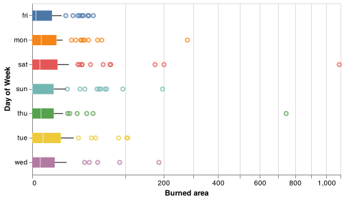

Figure 1. Distribution of burnt areas of the forest (sqrt transformed) per day of the week

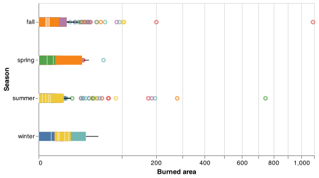

Figure 2. Distribution of burnt areas of the forest (sqrt transformed) per season

Figure 3 plots the pairwise relationships between the numerical variables of the dataset. We can see that the majority of the numerical variables have different ranges of values for each season. In addition to showing the patterns between the numerical variables, this plot also reveals the outliers in the data. For example, the variables such as `FFMC`, `DMC`, `DC`, `ISI` and `rain` contain outliers. Since we can see that `rain` has mostly values of 0, we drop this variable. To deal with the other outliers in the other variables, we use Cook’s distance for detecting outliers.

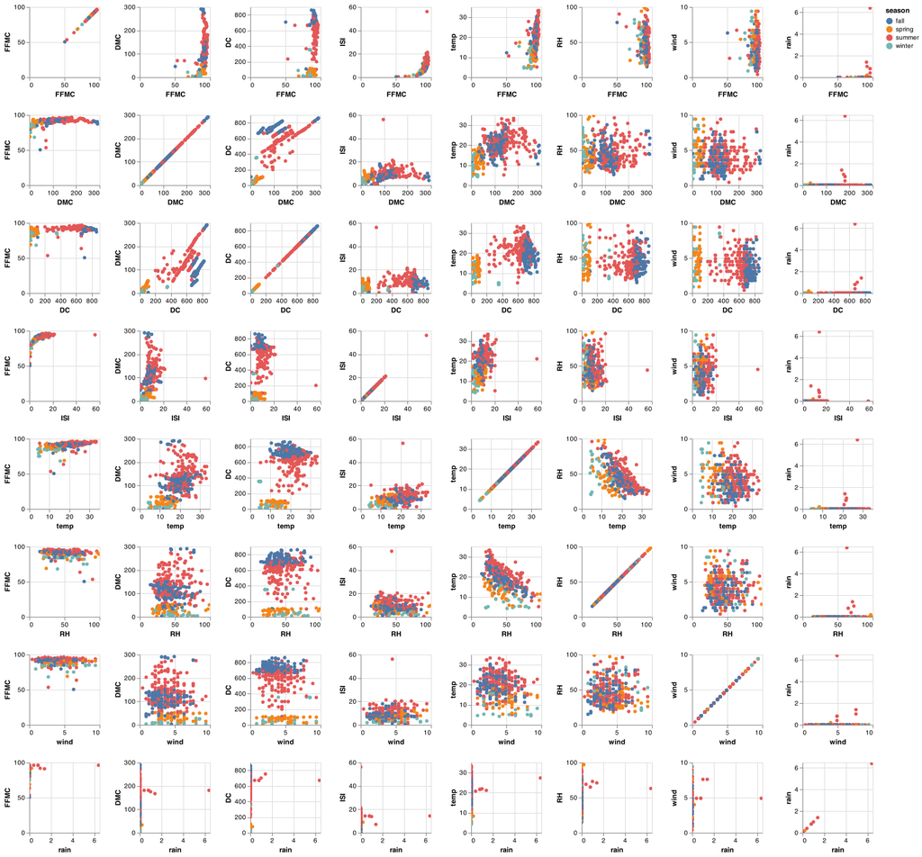

Figure 3. Pairwise relationships between the numerical variables per season

The Cook’s distance method, identified 4 observations as outliers as shown in figure 4. Consequently, we removed these 4 observations from our training data.

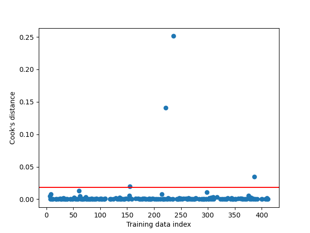

Figure 4. Cook’s distance outlier detection

We chose to perform regression using the Support Vector Regression (SVR) algorithm. To find the best model that predicted the burned forest area, we performed 10-fold cross-validation with Mean Absolute Error (MAE) and Root Mean Squared Error (RMSE) as the regression metrics. We observed that the optimal $C$ was $1.88$ and the optimal $gamma$ was $0.48$.

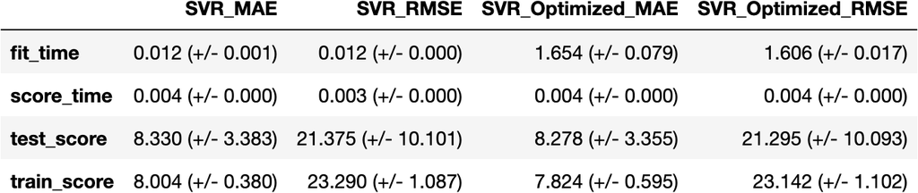

Table 1. Results from 10-fold cross-validation before and after hyperparameter optimization

Table 1 shows that the models improve slightly after hyperparameter tuning. The mean train scores and the mean validation scores using both MAE and RMSE seem to be fairly close to each other.

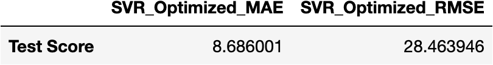

Table 2 shows that the model did fairly similar on the test data compared to the mean cross-validated validation scores when using MAE. However, the model seems to perform better on the validation sets compared to the test data when using RMSE. Furthermore, the MAE score is less than the RMSE score which is sensible as we should normally have $MAE \leq RMSE$. Both regression metrics express the average prediction error in the units of our target variable which is hectares. It is also worth noting that RMSE squares the errors before taking the average, thus giving a relatively high weight to large errors. Therefore, considering RMSE would be more useful when large errors are particularly undesirable.

Overall, we believe that the model performed fairly well on the test data as our target variable `area` has a range of values from $0$ to $1090.84$ hectares. Therefore, using both regression metrics, the errors provided in table 2 seem to be quite low in comparison to the range of values. Nonetheless, in the context of burned areas of fire, large errors are particularly undesirable, and as a result RMSE might be more useful since it gives more weight to the observations further away from the mean – that is, being off by 20 will be more than twice as bad as being off by 10.

Although our data has variables that are highly skewed and contains outliers, we believe we created a model that performs fairly well on unseen data. However, the high skewness of some variables could affect our model. Moreover, we used Cook’s distance to detect outliers. To make sure our detected outliers are robust, we can try another outlier detection method that confirms our results. To further improve this model in future with the hopes of creating a model with a lower prediction error, we can suggest several things. First, we would employ some feature selection algorithms. Moreover, we would try applying some transformations to the predictor variables such as applying log-normal, square root, etc. transformations. Additionally, we would try considering the interactions between the variables and use polynomial regression in our model. Furthermore, we could also try considering other regression algorithms such as the random forest algorithm, since it is robust to outliers and non-linear data.

# References

British Columbia, Government of. 2021. *Wildfire Averages*. Public Saftey; Emergency Services. https://www2.gov.bc.ca/gov/content/safety/wildfire-status/about-bcws/wildfire-statistics/wildfire-averages.

de Jonge, Edwin. 2018. *Docopt: Command-Line Interface Specification Language*. https://CRAN.R-project.org/package=docopt.

Dua, Dheeru, and Casey Graff. 2017. “UCI Machine Learning Repository.” University of California, Irvine, School of Information; Computer Sciences. http://archive.ics.uci.edu/ml.

Harris, Charles R., K. Jarrod Millman, Stéfan J van der Walt, Ralf Gommers, Pauli Virtanen, David Cournapeau, Eric Wieser, et al. 2020. “Array Programming with NumPy.” *Nature* 585: 357–62. https://doi.org/10.1038/s41586-020-2649-2.

Hunter, John D. 2007. “Matplotlib: A 2d Graphics Environment.” *Computing in Science & Engineering* 9 (3): 90–95.

McKinney, Wes et al. 2010. “Data Structures for Statistical Computing in Python.” In *Proceedings of the 9th Python in Science Conference*, 445:51–56. Austin, TX.

P. Cortex, A. Morais. 2007. *A Data Mining Approach to Predict Forest Fires Using Meteorological Data*. J. Neves, M. F. Santos; J. Machado Eds., New Trends in Artificial Intelligence, Proceedings of the 13th EPIA 2007 - Portuguese Conference on Artificial Intelligence. http://www3.dsi.uminho.pt/pcortez/fires.pdf.

Pedregosa, Fabian, Gaël Varoquaux, Alexandre Gramfort, Vincent Michel, Bertrand Thirion, Olivier Grisel, Mathieu Blondel, et al. 2011. “Scikit-Learn: Machine Learning in Python.” *Journal of Machine Learning Research* 12 (Oct): 2825–30.

R Core Team. 2019. *R: A Language and Environment for Statistical Computing*. Vienna, Austria: R Foundation for Statistical Computing. https://www.R-project.org/.

Seabold, Skipper, and Josef Perktold. 2010. “Statsmodels: Econometric and Statistical Modeling with Python.” In *9th Python in Science Conference*.

Van Rossum, Guido. 2020. *The Python Library Reference, Release 3.8.2*. Python Software Foundation.

Van Rossum, Guido, and Fred L. Drake. 2009. *Python 3 Reference Manual*. Scotts Valley, CA: CreateSpace.

Xie, Yihui. 2014. “Knitr: A Comprehensive Tool for Reproducible Research in R.” In *Implementing Reproducible Computational Research*, edited by Victoria Stodden, Friedrich Leisch, and Roger D. Peng. Chapman; Hall/CRC. http://www.crcpress.com/product/isbn/9781466561595.